# PROJECT AEON

### Jai Bhagat

[figure not shown]

# Scientific & Technical Requirements

[figure not shown]

## OUTLINE

### Engineering Focal Points

1. Environment
2. Experiment Control
3. Data Acquisition
4. Data Management
5. Data Visualization
6. Data Analysis
7. Animal Welfare

### Future Directions

1. Additional Platform Enhancements
2. Electrophysiology
3. Experiments

# Aeon Subgroup Structure

[figure not shown]

# The Team

[figure not shown]

# Engineering Focal Points

1. Environment
2. Experiment Control
3. Data Acquisition
4. Data Management
5. Data Visualization
6. Data Analysis
7. Animal Welfare

# Arena Design

[figure not shown]

## Food Patch and Nest Design

[figure not shown]

# Arenas in Action

[figure not shown]

[video not shown]

# Foraging: time-aligned 4s pre, 5s post pellet delivery

[video not shown]

### Engineering Focal Points

1. Environment
2. Experiment Control
3. Data Acquisition
4. Data Management
5. Data Visualization
6. Data Analysis
7. Animal Welfare

[figure not shown]

# Asynchronous, Reactive Updates in our Experiment GUI

[figure not shown]

### Arena Acquisition Devices

- USB Blackfly S 3 Cameras (1.6 MP up to 220 FPS)
- USB Dodotronic Ultramic UM250K Ultrasonic Microphones
- USB Harp Expander Output Boards
- USB ID-20LA 125 kHz USB RFID Readers

[figure not shown]

### Acquisition Computer Specs

- CPU: I9-13900k:
  - 32 Threads, 5.8 GHz Max
- GPU: RTX A4500:
  - ECC, RDMA, 20 GB VRAM
- RAM: Vengeance DDR5:
  - ECC, 128 GB, 5600 MHz
- SSD: Rocket:
  - 16 TB, R/W: 3.3 / 2.9 GB/s
- Mobo: Rog Maximus Z790 Extreme
  - Support for CPU, GPU, RAM, SSD
  - 10 GB ethernet port
  - Many USB 3.* ports: 13 -A, 5 -C

# Solving time-alignment with Harp + Bonsai

[figure not shown]

## Engineering Focal Points

1. Environment
2. Experiment Control
3. Data Acquisition
4. Data Management
5. Data Visualization
6. Data Analysis
7. Animal Welfare

# Aeon Data Pipelines

[figure not shown]

## Aeon Data Management Plan

- **How much data?**
  - Currently: ~700 GB / 24 hours
  - Future: up to ~7 TB / 24 hours
    - (But 🙏 for >2x lossless Ephys compression via MTSCOMP)
- **Storage:** 275 TB partition on Ceph (`/ceph/aeon/aeon/`)
- **Backup:** Ceph snapshots; tape back-up TBD
- **Network:** Aeon VLAN
- **Metadata:** JSON/YAML/MD format
- **Code and Data Accessibility:**
  - Some internally and publicly available now
  - All publicly available later

## Code Repository Structure

[figure not shown]

- Iterative Software Development Lifecycle
- Testing via PyTest and MSTest
- CI (*maybe CD?*) via GitHub Actions
- 🚧 Online Docs 🚧

### Data Storage

#### Ceph Data Storage

[figure not shown]

#### DataJoint MySQL Database

[figure not shown]

## Engineering Focal Points

1. Environment
2. Experiment Control
3. Data Acquisition
4. Data Management
5. Data Visualization
6. Data Analysis
7. Animal Welfare

# Low-level Python API

## Readers : Streams <- Devices <- Schemas

```python
# An example schema

from aeon.io.device import Device
import aeon.schema.core as stream
import aeon.schema.foraging as foraging

schema = DotMap(
    [
        Device("Patch1", stream.encoder, foraging.feeder, foraging.depletionFunction),
        Device("CameraTop", stream.video, stream.position, foraging.region),
    ]
)
schema.Patch1.Encoder
```

```
<aeon.io.reader.Encoder at 0x7f3f0ed1bd60>
```

```python
# View some of the devices in the 'exp02' and 'exp01' schemas

print(f"Exp02 devices: {list(exp02.keys())[2:6]}\n")
print(f"Exp01 devices: {list(exp01.keys())[1:5]}\n")
```

```
Exp02 devices: ['CameraTop', 'CameraEast', 'CameraNest', 'CameraNorth']

Exp01 devices: ['FrameTop', 'FrameEast', 'FrameGate', 'FrameNorth']
```

```python
# Load animal position data from both schemas

root_exp01 = "/ceph/aeon/aeon/data/raw/AEON/experiment0.1/"
root_exp02 = "/ceph/aeon/aeon/data/raw/AEON2/experiment0.2/"
exp01_pos = api.load(
    root_exp01,
    exp01.FrameTop.Position,
    start=pd.Timestamp("2021-10-06 08:00:00"),
    end=pd.Timestamp("2021-10-06 09:00:00")
)
exp02_pos = api.load(
    root_exp02,
    exp02.CameraTop.Position,
    start=pd.Timestamp("2022-10-03 06:00:00"),
    end=pd.Timestamp("2022-10-03 07:00:00")
)
display(exp01_pos.tail())
display(exp02_pos.head())
```

| time | x | y | angle | major | minor | area | id |
| --- | --- | --- | --- | --- | --- | --- | --- |
| 2021-10-06 08:59:59.900991917 | 591.324707 | 260.302368 | 1.013295 | 27.946606 | 19.449930 | 560.0 | NaN |
| 2021-10-06 08:59:59.921023846 | 591.377991 | 260.176636 | 1.029197 | 27.642103 | 19.596058 | 559.5 | NaN |
| 2021-10-06 08:59:59.940991879 | 591.129456 | 260.062927 | 1.019339 | 27.305264 | 19.682451 | 553.5 | NaN |
| 2021-10-06 08:59:59.961023808 | 590.856262 | 260.074310 | 0.993847 | 26.591646 | 19.888531 | 545.0 | NaN |
| 2021-10-06 08:59:59.980991840 | 590.703552 | 260.061951 | 0.993873 | 26.135967 | 19.946396 | 538.0 | NaN |

| time | x | y | angle | major | minor | area | id |
| --- | --- | --- | --- | --- | --- | --- | --- |
| 2022-10-03 06:00:00.013088226 | 160.410400 | 552.164856 | 1.518157 | 16.847296 | 13.713420 | 186.0 | 0.0 |
| 2022-10-03 06:00:00.033055782 | 160.292984 | 552.202637 | 1.555706 | 16.881168 | 13.328964 | 190.0 | 0.0 |
| 2022-10-03 06:00:00.053088188 | 160.355728 | 552.213623 | 1.551487 | 16.962437 | 13.509223 | 193.5 | 0.0 |
| 2022-10-03 06:00:00.073056221 | 160.092773 | 552.511780 | -1.541666 | 16.954584 | 12.971062 | 212.0 | 0.0 |
| 2022-10-03 06:00:00.093088150 | 160.112946 | 552.559204 | -1.470261 | 16.806320 | 13.165533 | 212.5 | 0.0 |

# Datajoint API

```python
# Example: View some daily statistics

analysis.VisitSummary & f"visit_start >= '2022-09-26'" & f"visit_start <= '2022-10-10'"
```

| experiment_name e.g exp0-a | subject | place User-friendly name of a 'place' animals can visit - e.g. nest, arena, foodpatch | visit_start | visit_date | day_duration total duration (in hours) | total_distance_travelled (m) total distance the animal travelled during this visit | total_pellet_count total pellet delivered (triggered) for all patches during this visit | total_wheel_distance_travelled total wheel travelled distance for all patches |
| --- | --- | --- | --- | --- | --- | --- | --- | --- |
| exp0.2-r0 | BAA-1102223 | environment | 2022-09-26 10:37:39.908189 | 2022-09-26 | 13.372 | 2781.11 | 145 | 9667.27 |
| exp0.2-r0 | BAA-1102223 | environment | 2022-09-26 10:37:39.908189 | 2022-09-27 | 24.0 | 2890.26 | 149 | 14905.1 |
| exp0.2-r0 | BAA-1102223 | environment | 2022-09-26 10:37:39.908189 | 2022-09-28 | 24.0 | 2588.45 | 138 | 13780.7 |
| exp0.2-r0 | BAA-1102223 | environment | 2022-09-26 10:37:39.908189 | 2022-09-29 | 24.0 | 2607.73 | 187 | 18442.4 |
| exp0.2-r0 | BAA-1102223 | environment | 2022-09-26 10:37:39.908189 | 2022-09-30 | 24.0 | 2260.62 | 162 | 29183.6 |

...

Total: 16

```python
# Aggregate over subjects and get mean values

subject_summary_query = Experiment.Subject.aggr(
    analysis.VisitSummary & f"visit_start >= '2022-09-26'" & f"visit_start <= '2022-10-10'",
    mean_distance="AVG(total_distance_travelled)",
    mean_pellet="AVG(total_pellet_count)",
    mean_wheel_distance="AVG(total_wheel_distance_travelled)",
)
subject_summary_query
```

| experiment_name e.g exp0-a | subject | mean_distance calculated attribute | mean_pellet calculated attribute | mean_wheel_distance calculated attribute |
| --- | --- | --- | --- | --- |
| exp0.2-r0 | BAA-1102223 | 2455.364158630371 | 149.6250 | 17797.726623535156 |
| exp0.2-r0 | BAA-1102224 | 2058.92586517334 | 126.6250 | 27526.142211914062 |

Total: 2

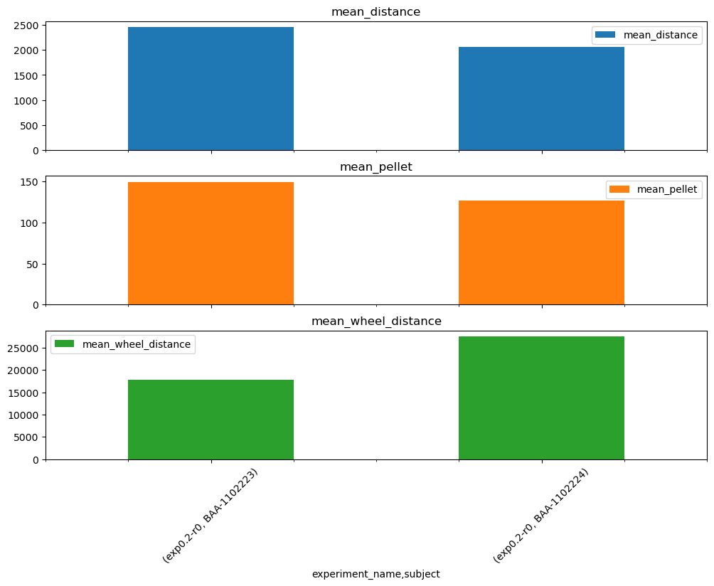

```python
# Fetch data back in the form of pandas DataFrame and plot it

subject_summary = subject_summary_query.fetch(format='frame')
subject_summary = subject_summary.astype(  # ensure datatype is float
    {'mean_distance': float,
     'mean_pellet': float,
     'mean_wheel_distance': float
    }
)
subject_summary.plot.bar(subplots=True, figsize=(12, 8), rot=45);
```

# Web Interfaces

- [Dashboard](http://192.168.234.1:7777)
- [Sci-viz](https://www.swc.ucl.ac.uk/aeon/login)

# Weight & ID Tracking

[figure not shown]

[video not shown]

## Engineering Focal Points

1. Environment
2. Experiment Control
3. Data Acquisition
4. Data Management
5. Data Visualization
6. Data Analysis
7. Animal Welfare

## Animal Welfare

- Robust Weight Tracking
- Robust ID Tracking
- Status & Alert Notifications
  - Via Webhooks via Teams
  - Hourly status updates
  - Animal alerts:
    - Weight
    - Activity
    - *Online Behaviour Classification (e.g. Fighting)*
  - System alerts:
    - Hardware device issues (e.g. dropped frames, non-responsive feeders)
    - Software issues (e.g. abnormal system usage, storage capacity, lost synchronization)

## Future Directions

1. Additional Platform Enhancements
2. Electrophysiology
3. Social, Continual Learning, Policy-switching Experiments

## Additional Platform Enhancements

- Closed loop feedback between Bonsai and Database
- Web Interface Video Streamer
- Latent behavioral and neural state classification (e.g. using CEBRA)

## Electrophysiology

OpenEphys Onix Headstages for Neuropixels 2!

[figure not shown]

## Electrophysiology

Auto-commutation via Kalman smoothing

[video not shown]

[figure not shown]

## Long-term, Social Behavior Questions

In a noisy and changing environment, do mice:

1. Exhibit social behaviour?

a. Interact more or less than expected?  
b. Exert more or less energy / power than expected?

2. Establish a social hierarchy?  
   a. Change ranks in the social hierarchy?  
   b. Gain resources from foraging consistent with their ranking in a social hierarchy?
3. Share information that maximises their resources gained from foraging?

a. Learn to explore until finding the best patch?

4. Compete over resources gained from foraging?
5. Learn to cooperate to maximise resources gained from foraging?

# Potential Implicated Brain Regions

[figure not shown]

# Summary

## Engineering Focal Points

1. Environment
2. Experiment Control
3. Data Acquisition
4. Data Management
5. Data Visualization
6. Data Analysis
7. Animal Welfare

## Future Directions

1. Additional Platform Enhancements
2. Electrophysiology
3. Experiments